# Arbeitspaket (AP) 1: Advanced Data Collection Methods

### Persönliche Angaben (bitte ergänzen)

| Vorname: |  |
| --- | --- |
| Nachname: |  |
| Immatrikulationsnummer: |  |
| Modul: | Data Science |
| Prüfungsdatum / Raum / Zeit: | 11.11.2024 / Raum: SF O3.54 / 8:00 – 11:45 |
| Erlaubte Hilfsmittel: | w.MA.XX.DS.24HS (Data Science) Open Book, Eigener Computer, Internet-Zugang |
| Nicht erlaubt: | Nicht erlaubt ist der Einsatz beliebiger Formen von generativer KI (z.B. Copilot, ChatGPT) sowie beliebige Formen von Kommunikation oder Kollaboration mit anderen Menschen. |

## Bewertungskriterien

### **(max. erreichbare Punkte: 48)**

[output not shown]

## Python Libraries und Settings

```python
# Libraries
import os
import re
import json
import requests
import feedparser
import pandas as pd
import yfinance as yf
from zipfile import ZipFile
from bs4 import BeautifulSoup
from datetime import datetime
import matplotlib.pyplot as plt
from wordcloud import WordCloud
from pandas import json_normalize
from lxml import html as lxml_html

from pycoingecko import CoinGeckoAPI
cg = CoinGeckoAPI()

# Ignore warnings
import warnings
warnings.filterwarnings('ignore')

# Show current working directory
print(os.getcwd())
```

```
u:\Lektionen\DS_HS2024\MEP_HS2024\Block_02\Loesungen_LN_II\AP01
```

## **Vorbereitung (Dieser Teil wird nicht bewertet!)**

#### **1.) Starten Sie eine GitHub Codespaces Instanz auf Basis Ihres Forks des folgenden GitHub Repositories:**

##### GitHub-Repository: https://github.com/mario-gellrich-zhaw/data_ingestion

## **Aufgaben (Dieser Teil wird bewertet!)**

**Hinweise zu den folgenden Aufgabenstellungen:**

- Beachten Sie auch die zu jeder Aufgabenstellung zugehörenden Details zu Aufgabenstellung.
- Lösen Sie jede Aufgabe mit Hilfe von Python Code. Integrieren Sie den Python Code in die Code-Zellen der jeweiligen Aufgabe.
- Stellen Sie die Lösung(en) jeder Aufgabe ganz oder in Teilen (z.B. erste 5 Zeilen) eines DataFrames im Jupyter Notebook dar.
- Wenn in den Aufgaben in Bezug auf das Datum vom 'aktuellen Tag' gesprochen wird, ist der Tag der Durchführung dieses Leistungsnachweises gemeint.

#### **Aufgabe (1): Importieren Sie jedes der über den folgenden Codezellen angegebenen Files in ein eigenes pandas DataFrame.**

**Details zur Aufgabenstellung:**

- Sie finden die Files im Order 'Data'.
- Berücksichtigen Sie die Ablage der Files beim Einlesen (z.B. Pfad zum Einlesen von 'BigmacPrice.csv' is: './Data/BigmacPrice.csv').
- Zeigen Sie mit Hilfe eines geeigneten Python Befehls die Dimension des pandas DataFrames (Anzahl Zeilen und Spalten) im Jupyter Notebook an.
- Stellen sie die erstellten DataFrames entweder ganz oder in Teilen (z.B. die ersten 5 Zeilen) im Jupyter Notebook dar.

**(max. erreichbare Punkte: 4)**

#### Importieren von 'BigmacPrice.csv'

```python
# Import File 'BigmacPrice.csv' in eine Pandas DataFrame
bigmac = pd.read_csv('./Data/BigmacPrice.csv',
                     sep=',',
                     encoding='utf-8')

# Anzeigen der Anzahl Zeilen und Spalten im DataFrame
print(bigmac.shape)

# Anzeigen des DataFrames
bigmac.head()
```

```
(1946, 6)
```

|  | date | currency_code | name | local_price | dollar_ex | dollar_price |
| --- | --- | --- | --- | --- | --- | --- |
| 0 | 2000-04-01 | ARS | Argentina | 2.50 | 1 | 2.50 |
| 1 | 2000-04-01 | AUD | Australia | 2.59 | 1 | 2.59 |
| 2 | 2000-04-01 | BRL | Brazil | 2.95 | 1 | 2.95 |
| 3 | 2000-04-01 | GBP | Britain | 1.90 | 1 | 1.90 |
| 4 | 2000-04-01 | CAD | Canada | 2.85 | 1 | 2.85 |

#### Importieren von 'CarData.xml'

```python
# Import File 'CarData.xml'
cars = pd.read_xml('./Data/CarData.xml',
                     encoding='utf-8')

# Anzeigen der Anzahl Zeilen und Spalten im DataFrame
print(cars.shape)

# Anzeigen des DataFrames
cars.head()
```

```
(1000, 10)
```

|  | car_id | make | type | year | hp | mileage | price | doors | color | vin_number |
| --- | --- | --- | --- | --- | --- | --- | --- | --- | --- | --- |
| 0 | 1 | Chevrolet | Sedan | 1991 | 158 | 25040 | 17145.80 | 3 | Orange | A4BEEC1BAEAE4759B02FB952F5FDF7D0 |
| 1 | 2 | BMW | Wagon | 1991 | 465 | 137449 | 29727.51 | 5 | Red | 3D154B9E846947C0BACB1729E4F3157A |
| 2 | 3 | Kia | Van | 2001 | 189 | 202308 | 73312.00 | 4 | Red | E1AF7108C06E4501BFD5876FD733AB65 |
| 3 | 4 | Toyota | SUV | 2011 | 117 | 123661 | 22342.98 | 5 | Black | 880B573230AA42488E2D97F065BB0681 |
| 4 | 5 | Nissan | SUV | 2004 | 339 | 256696 | 53094.74 | 5 | Blue | 138ECF9A0D8748F99F401942FD139103 |

#### Importieren von 'ChickenData.xlsx'

```python
# Import File 'ChickenData.xlsx'
chickens = pd.read_excel('./Data/ChickenData.xlsx',
                     sheet_name='Chickens')

# Anzeigen der Anzahl Zeilen und Spalten im DataFrame
print(chickens.shape)

# Anzeigen des DataFrames
chickens.head()
```

```
(100, 4)
```

|  | chicken_id | weight | breed | eggs_per_year |
| --- | --- | --- | --- | --- |
| 0 | 1 | 2435.836917 | New Hampshire Red | 158 |
| 1 | 2 | 2157.180545 | Australorp | 273 |
| 2 | 3 | 2558.418035 | New Hampshire Red | 153 |
| 3 | 4 | 2679.200608 | Plymouth Rock | 268 |
| 4 | 5 | 2556.855145 | Australorp | 360 |

#### Importieren von 'HotelData.json'

```python
# Import File 'HotelData.json'
hotels = pd.read_json('./Data/HotelData.json')

# Anzeigen der Anzahl Zeilen und Spalten im DataFrame
print(hotels.shape)

# Anzeigen des DataFrames
hotels.head()
```

```
(456, 5)
```

|  | type | generator | copyright | timestamp | features |
| --- | --- | --- | --- | --- | --- |
| 0 | FeatureCollection | overpass-turbo | The data included in this document is from www... | 2024-10-27 16:52:02+00:00 | {'type': 'Feature', 'properties': {'@id': 'rel... |
| 1 | FeatureCollection | overpass-turbo | The data included in this document is from www... | 2024-10-27 16:52:02+00:00 | {'type': 'Feature', 'properties': {'@id': 'rel... |
| 2 | FeatureCollection | overpass-turbo | The data included in this document is from www... | 2024-10-27 16:52:02+00:00 | {'type': 'Feature', 'properties': {'@id': 'rel... |
| 3 | FeatureCollection | overpass-turbo | The data included in this document is from www... | 2024-10-27 16:52:02+00:00 | {'type': 'Feature', 'properties': {'@id': 'way... |
| 4 | FeatureCollection | overpass-turbo | The data included in this document is from www... | 2024-10-27 16:52:02+00:00 | {'type': 'Feature', 'properties': {'@id': 'way... |

#### **Aufgabe (2): Extrahieren Sie aus dem File 'BookStore.html' die Preise der Bücher mit Hilfe eines geeigneten XPath.**

**Details zur Aufgabenstellung:**

- Sie finden das HTML-File 'BookStore.html' im Order 'Data'.
- Komplettieren Sie für das Lösen der Aufgabe den unfertigen XPath im folgenden Python Code.
- Beachten Sie, dass nur ein einziger XPath für das Extrahieren aller Preise notwendig ist.
- Stellen Sie die extrahierten Preise im Jupyter Notebook dar.
- Tipp: Für das Testen des XPath können Sie diesen Online XPath-Tester verwenden: http://xpather.com

**(max. erreichbare Punkte: 4)**

```python
# Import File 'BookStore.html'
with open('./Data/BookStore.html', 'r', encoding='utf-8') as file:
    html_content = file.read()

# Parsen des HTML-Contents
tree = lxml_html.fromstring(html_content)

# XPath zum Extrahieren der Buchpreise (bitte komplettieren)
try:
    prices = tree.xpath('/html/body/div/section/div/div/p[2]/text()')
except:
    prices = [] # Ausgabe einer leeren Liste, falls der XPath nicht korrekt ist

# Anzeigen der extrahierten Buchpreise
print("Extracted Book Prices:", prices)
```

```
Extracted Book Prices: ['$10.99', '$9.99', '$12.99']
```

#### **Aufgabe (3): Erstellen Sie ein pandas DataFrame mit den Daten aus der folgenden Tabelle (1), und speichern Sie dieses als XML-File ab.**

**Details zur Aufgabenstellung:**

- Speichern Sie das erstellte XML-File als 'SmartphoneData.xml' im Ordner 'Data'.
- Stellen Sie das erstellte DataFrame im Jupyter Notebook dar.

Tipp: Beim Erstellen eines Dataframes wird typischerweise zuerst ein Python dictionary erstellt und dieses anschliessend in ein DataFrame umgewandelt.

Tabelle (1): Smartphone Data

| Marke | Modell | Baujahr | Farbe | Preis |
| --- | --- | --- | --- | --- |
| Apple | iPhone 12 | 2020 | Schwarz | 799 |
| Samsung | Galaxy S21 | 2021 | Weiß | 999 |
| Google | Pixel 5 | 2020 | Grün | 699 |
| OnePlus | 8 Pro | 2020 | Blau | 899 |

**(max. erreichbare Punkte: 4)**

```python
# Erstellen des DataFrames aus der gegebenen Tabelle
data = {
    'Marke': ['Apple', 'Samsung', 'Google', 'OnePlus'],
    'Modell': ['iPhone 12', 'Galaxy S21', 'Pixel 5', '8 Pro'],
    'Baujahr': [2020, 2021, 2020, 2020],
    'Farbe': ['Schwarz', 'Weiß', 'Grün', 'Blau'],
    'Preis': [799, 999, 699, 899]
}

df = pd.DataFrame(data)

# Abspeichern des DataFrames als XML-Datei
df.to_xml('./Data/SmartphoneData.xml', index=False)

# Anzeigen des DataFrames
df
```

|  | Marke | Modell | Baujahr | Farbe | Preis |
| --- | --- | --- | --- | --- | --- |
| 0 | Apple | iPhone 12 | 2020 | Schwarz | 799 |
| 1 | Samsung | Galaxy S21 | 2021 | Weiß | 999 |
| 2 | Google | Pixel 5 | 2020 | Grün | 699 |
| 3 | OnePlus | 8 Pro | 2020 | Blau | 899 |

**Details zur Aufgabenstellung:**

**(max. erreichbare Punkte: 4)**

```python
# Erstellen eines leeren Zip-Archivs
zipObj = ZipFile('./Data/MyData.zip', 'w')

# Hinzufügen der Dateien zum Zip-Archiv
zipObj.write('./Data/BigmacPrice.csv')
zipObj.write('./Data/BookStore.html')
zipObj.write('./Data/ChickenData.xlsx')
zipObj.write('./Data/HotelData.json')

# Schliessen des Zip-Archivs
zipObj.close()
```

#### **Aufgabe (5): Beziehen Sie Daten zu Cryptowährungen mit Hilfe der Coingecko Web API.**

**Details zur Aufgabenstellung:**

- Verwenden Sie die folgenden Bezeichnungen (Ids) der Cryptowährungen für die Server-Anfragen: **binancecoin, cardano, polkadot, solana**.
- Fragen Sie folgende Daten ab (Währung = EUR):
  - Markkapitlisierung (include_market_cap='true')
  - 24 Stunden Volumen (include_24hr_vol='true')
  - 24 Stunden Veränderung (include_24hr_change='true')
  - Datum des letzten Updates (include_last_updated_at='true')
- Wandeln Sie die Daten in ein DataFrame um und stellen Sie dieses im Jupyter Notebook dar.
- Tipp: data = cg.get_price() speichert die Daten in ein Python dictionary. Dieses kann mit df = pd.DataFrame(data) in ein DataFrame umgewandelt werden.

**(max. erreichbare Punkte: 8)**

```python
# Beziehen der Daten mit Hilfe der Coingecko Web API
data = cg.get_price( ids='binancecoin, cardano, polkadot, solana',
                     vs_currencies=['eur'],
                     include_market_cap='true',
                     include_24hr_vol='true',
                     include_24hr_change='true',
                     include_last_updated_at='true')

# Speichern der Daten in einem pandas DataFrame
df = pd.DataFrame(data)

# Anzeigen des DataFrames
df
```

|  | binancecoin | cardano | polkadot | solana |
| --- | --- | --- | --- | --- |
| eur | 5.984500e+02 | 6.787110e-01 | 5.270000e+00 | 2.261300e+02 |
| eur_market_cap | 8.730478e+10 | 2.428624e+10 | 7.580904e+09 | 1.067309e+11 |
| eur_24h_vol | 2.003432e+09 | 3.767955e+09 | 1.032446e+09 | 1.158916e+10 |
| eur_24h_change | 8.714643e-01 | -4.647025e+00 | 2.661393e+00 | 9.809026e+00 |
| last_updated_at | 1.731843e+09 | 1.731843e+09 | 1.731843e+09 | 1.731843e+09 |

#### **Aufgabe (6): Beziehen Sie Börsendaten zur Tesla-Aktie mit Hilfe der Yahoo-Finance Web API.**

**Details zur Aufgabenstellung:**

- Die Tesla Aktie hat das Kürzel TSLA.
- Definieren Sie '2023-01-01' als Startdatum für die Abfrage der Börsendaten.
- Verwenden Sie die Python Library 'datetime' für die Erstellung des Enddatums (aktueller Tag).
- Speichern Sie die Börsendaten in einem pandas DataFrame ab.
- Stellen Sie die Daten der fünf aktuellsten Börsentage im Jupyter Notebook dar.
- Hinweis: Die neusten Daten aus der Yahoo-Finance Web API sind jeweils vom Vortag.

**(max. erreichbare Punkte: 8)**

```python
# Erstellen eines Datumsobjekts mit dem aktuellen Datum und der aktuellen Uhrzeit
today = datetime.now().strftime("%Y-%m-%d")
print('Today is:', today)

# Beziehen der Tesla Aktienkurse von Yahoo Finance
data = yf.download('TSLA', start = '2023-01-01', end = today, progress=False)

# Anzeigen der Anzahl Zeilen und Spalten im DataFrame
print('Dimension:', data.shape)

# Anzeigen des DataFrames mit den Daten der fünf aktuellsten Börsentage
data.tail()
```

```
Today is: 2024-11-17
Dimension: (472, 6)
```

| Price Ticker Date | Adj Close TSLA | Close TSLA | High TSLA | Low TSLA | Open TSLA | Volume TSLA |
| --- | --- | --- | --- | --- | --- | --- |
| 2024-11-11 00:00:00+00:00 | 350.000000 | 350.000000 | 358.640015 | 336.000000 | 346.299988 | 210521600 |
| 2024-11-12 00:00:00+00:00 | 328.489990 | 328.489990 | 345.839996 | 323.309998 | 342.739990 | 155726000 |
| 2024-11-13 00:00:00+00:00 | 330.239990 | 330.239990 | 344.600006 | 322.500000 | 335.850006 | 125405600 |
| 2024-11-14 00:00:00+00:00 | 311.179993 | 311.179993 | 329.980011 | 310.369995 | 327.690002 | 120726100 |
| 2024-11-15 00:00:00+00:00 | 320.720001 | 320.720001 | 324.679993 | 309.220001 | 310.570007 | 114128900 |

#### **Aufgabe (7): Beziehen Sie mit Hilfe der Overpass Turbo Web API Daten zu den Tankstellen in der Schweiz.**

**Details zur Aufgabenstellung:**

- Tankstellen sind mit dem key:value Paar "amenity"="fuel" in der OpenStreetMap Map-Feature Übersicht angegeben.
- Speichern Sie die Daten in einem File 'petrol_station.json' im Order 'Data' ab.
- Lesen Sie die Daten zusätzlich in ein pandas DataFrame und zeigen Sie dieses ganz oder in Teilen (z.B. erste 5 Zeilen) an.
- Tipp: Auf der Webseite: https://overpass-turbo.eu können Sie Overpass Turbo Abfragen testen.

**(max. erreichbare Punkte: 8)**

```python
# Overpass API URL
url = 'http://overpass-api.de/api/interpreter'

# Overpass turbo Abfrage-String
query = f"""
        [out:json];
        area["ISO3166-1"="CH"][admin_level=2];
        node ["amenity"="fuel"](area);
        out;"""

# Web API Anfrage
r = requests.get(url, params={'data': query})
data = r.json()['elements']

# Speichern der Daten in einer JSON-Datei
with open('./Data/petrol_station.json', 'w') as json_file:
    json.dump(data, json_file)

# Speichern der Daten in einem Pandas DataFrame und Anzeigen des DataFrames
df = json_normalize(data)
df.head(5)
```

|  | type | id | lat | lon | tags.amenity | tags.brand | tags.brand:wikidata | tags.name | tags.fuel:diesel | tags.operator | ... | tags.construction | tags.dog | tags.payment:hubrol_card | tags.fuel:lng | tags.fuel:petrol | tags.outdoor_seating | tags.operator:wikidata | tags.maxheight:signed | tags.currency:others | tags.payment:euroshell |
| --- | --- | --- | --- | --- | --- | --- | --- | --- | --- | --- | --- | --- | --- | --- | --- | --- | --- | --- | --- | --- | --- |
| 0 | node | 734402 | 46.690599 | 7.668189 | fuel | Eni | Q565594 | Eni | NaN | NaN | ... | NaN | NaN | NaN | NaN | NaN | NaN | NaN | NaN | NaN | NaN |
| 1 | node | 1228781 | 46.878598 | 7.542326 | fuel | BP | NaN | NaN | yes | BP | ... | NaN | NaN | NaN | NaN | NaN | NaN | NaN | NaN | NaN | NaN |
| 2 | node | 5702030 | 46.680546 | 7.827412 | fuel | Migrol | Q1747771 | Migrol | NaN | NaN | ... | NaN | NaN | NaN | NaN | NaN | NaN | NaN | NaN | NaN | NaN |
| 3 | node | 5702071 | 46.683415 | 7.844559 | fuel | Avia | Q300147 | Avia | NaN | Avia | ... | NaN | NaN | NaN | NaN | NaN | NaN | NaN | NaN | NaN | NaN |
| 4 | node | 8082505 | 46.683817 | 7.664427 | fuel | NaN | NaN | NaN | NaN | NaN | ... | NaN | NaN | NaN | NaN | NaN | NaN | NaN | NaN | NaN | NaN |

5 rows × 196 columns

#### **Aufgabe (8): Beziehen und Visualisieren Sie die aktuellen News-Feed (RSS-Feed) Daten der New York Times.**

**Details zur Aufgabenstellung:**

- Verwenden Sie diese URL zum RSS-Feed der New York Times Welt-Nachrichten: https://rss.nytimes.com/services/xml/rss/nyt/World.xml.
- Beziehen Sie die RSS-Feeds und extrahieren sie die Titel der Artikel aus den RSS-Feed Einträgen.
- Zeigen Sie die Titel der RSS-Feed Einträge im Jupyter Notebook an.
- Erstellen Sie eine Graphik mit einer Word-Cloud der Titel der RSS-Feed Einträge und stellen Sie diese im Jupyter Notebook dar.

**(max. erreichbare Punkte: 8)**

```
Article Titles:
‘No Use for Hatred’: A Village Seeks to Move On From a U.S. Massacre
Russia Launches Major Attack on Power Grid, Ukraine Says
Haiti Has Big Problems and Few Solutions
Israeli Strikes in Central and Northern Gaza Kill More Than 30 People
Biden and Xi Meet, Delivering Messages Seemingly Intended for Trump
At a Ukraine Maternity Clinic, Deaths From an Airstrike Shatter a Community
China Stabbing Kills at Least 8 People
Young Gazans Reach Global Audiences With Videos of Everyday Life in War
Bitter Infighting Divides Russian Opposition
Vladimir Shklyarov, Star Russian Ballet Dancer, Dies at 39
South Africa Police Try Siege Tactics on Illegal Mining, Igniting Debate
As Xi and Biden Meet, Trump and Uncertainty Loom Large
North Korea Blasts Unbearable Sounds To South Korea
Ten Newborns Die in India Hospital Fire
Barnard’s Star Finally Has a Planet, and Possibly More
Why Trump’s Space for Deal-Making in the Middle East Has Shrunk
Man Hiding Tarantulas, Centipedes and Ants Is Stopped From Boarding Flight
Satisfying vs. Productive
Conversations With Murray Sinclair
Israel Strikes Near Beirut as Two Medics Killed in South Lebanon
Democrats’ Message at COP29 Climate Talks: Don’t Panic
Typhoon Man-yi Pounds the Philippines With Rain and High Winds
Biden Discusses With Allies ‘Dangerous’ Cooperation Between Russia and North Korea
Iran Told U.S. That It’s Not Trying to Kill Trump
Trump Will Encounter a Very Different Middle East in His Second Term
Princess Yuriko, Oldest Member of Japan’s Imperial Family, Dies at 101
Taylor Swift to Tour in Canada After Trudeau Issues Plea on Social Media
Putin Talks With German Chancellor, Breaking Ice With the West
A Whole New Ballgame
Gaza War Strains Europe’s Efforts at Social Cohesion
A Tiny Gladiator Tells of the Reach of Roman Empire Celebrity
Nuclear Power Was Once Shunned at Climate Talks. Now, It’s a Rising Star.
Moldova Uncovers Fraudulent Scheme to Get Criminals Off Interpol Blacklist
Israel Pounds Area Near Beirut Amid Signs of a Widening Offensive
Sri Lankan Leader’s Leftist Coalition Wins Elections
Court Hears New York Times Case Against European Commission Over Vaccine Deal
Engineers Discover a 132-Year-Old Message in a Bottle in a Scottish Lighthouse
Lebanese Fear That Wherever the Displaced Go, Israeli Bombs Will Follow
Can These Ex-Hollywood Chimps Find a Place Among the Apes?
Fire in Retirement Home in Spain Leaves at Least 10 Dead
New Zealand Parliament Suspended as Maori Lawmakers Perform Haka to Protest Bill
Why North Korea Is Building Drones
Friday Briefing
In Moscow, Trump’s Victory Is Welcomed, But Warily
Argentina Mulls Exiting Paris Climate Deal
Stress From Fireworks Killed Baby Red Panda, Zoo in Scotland Says
Murray Sinclair, 73, Who Reframed Indigenous Relations in Canada, Dies
Yiannis Boutaris, Vintner, Animal Defender and Greek Mayor, Dies at 82
Elon Musk Met With Iran’s U.N. Ambassador, Iranian Officials Say
Friday Briefing: Dismay Over Trump’s Picks
France-Israel Soccer Match is Overshadowed by Amsterdam Attack
New York Joins a Global City Club, With a Deal on Congestion Pricing
Chemist Identifies Mystery ‘Blobs’ Washing Up in Newfoundland
Pope Francis Wants to Save the Environment. He Can Start With a Tree.
Israel Strikes Humanitarian Zone in Gaza
Norway Apologizes for Forced Assimilation of Sami and Other Minorities
Israel Bombs Targets in Syria, and Keeps Up Strikes in Lebanon
Investigators Assess if Netanyahu’s Aides Forged Oct. 7 Phone Records
Typhoon Usagi Slams Into the Philippines
Thursday Briefing
```

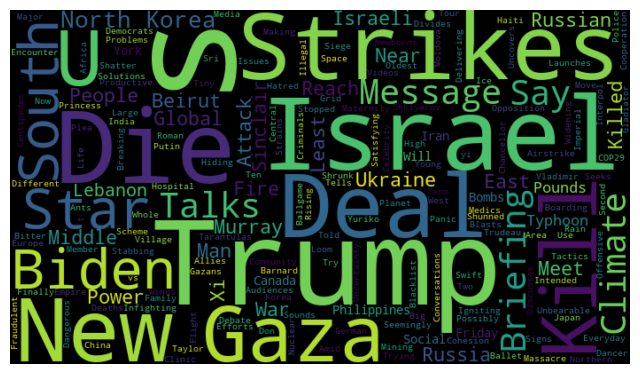

```python
# Parsen des RSS-News Feed von der New York Times World News Webseite
feed = feedparser.parse("https://rss.nytimes.com/services/xml/rss/nyt/World.xml")

# Extrahieren der RSS-Feed Einträge
feed_entries = feed.entries

# Initialisieren des WordCloud-Texts
wordcloud_text = ""

# Loop für Anzeige des Artikel-Titels
print("Article Titles:")
for entry in feed.entries:

    # Extrahieren des Artikel-Titels
    article_title = entry.title

    # Anhängen des Artikel-Titels an den WordCloud-Text
    wordcloud_text += f"{article_title} "

    # Anzeige des Artikel-Titels
    print(f"{article_title}")

# Generieren der WordCloud
wordcloud = WordCloud(width=700,
                      height=400,
                      background_color='black').generate(wordcloud_text)

# Anzeigen der WordCloud
plt.figure(figsize=(8, 6))
plt.imshow(wordcloud, interpolation='bilinear')
plt.axis('off')  # Hide the axes
plt.show()
```

### Jupyter notebook --footer info-- (please always provide this at the end of each notebook)

```python
import os
import platform
import socket
from platform import python_version
from datetime import datetime

print('-----------------------------------')
print(os.name.upper())
print(platform.system(), '|', platform.release())
print('Datetime:', datetime.now().strftime("%Y-%m-%d %H:%M:%S"))
print('Python Version:', python_version())
print('IP Address:', socket.gethostbyname(socket.gethostname()))
print('-----------------------------------')
```

```
-----------------------------------
NT
Windows | 11
Datetime: 2024-11-17 12:36:40
Python Version: 3.12.4
IP Address: 172.27.5.229
-----------------------------------
```